# Data Science and Business Analytics Intern @ The Sparks Foundation

## State-wise Analysis with respect to Sales, Discount and Profit

```python
df['State'].value_counts().head(15)
```

```
California        2001
New York          1128
Texas              985
Pennsylvania       587
Washington         506
Illinois           492
Ohio               469
Florida            383
Michigan           255
North Carolina     249
Virginia           224
Arizona            224
Georgia            184
Tennessee          183
Colorado           182
Name: State, dtype: int64
```

```python
df_state= df.groupby(['State'])[['Sales', 'Discount', 'Profit']].mean()
df_state.head(15)
```

| State | Sales | Discount | Profit |
| --- | --- | --- | --- |
| Alabama | 319.846557 | 0.000000 | 94.865989 |
| Arizona | 157.508933 | 0.303571 | -15.303235 |
| Arkansas | 194.635500 | 0.000000 | 66.811452 |
| California | 228.729451 | 0.072764 | 38.171608 |
| Colorado | 176.418231 | 0.316484 | -35.867351 |
| Connecticut | 163.223866 | 0.007317 | 42.823071 |
| Delaware | 285.948635 | 0.006250 | 103.930988 |
| District of Columbia | 286.502000 | 0.000000 | 105.958930 |
| Florida | 233.612815 | 0.299347 | -8.875461 |
| Georgia | 266.825217 | 0.000000 | 88.315453 |
| Idaho | 208.689810 | 0.085714 | 39.367767 |
| Illinois | 162.939230 | 0.390041 | -25.625787 |
| Indiana | 359.431946 | 0.000000 | 123.375411 |
| Iowa | 152.658667 | 0.000000 | 39.460397 |
| Kansas | 121.429583 | 0.000000 | 34.851813 |

**1. Statewise Sale Analysis**

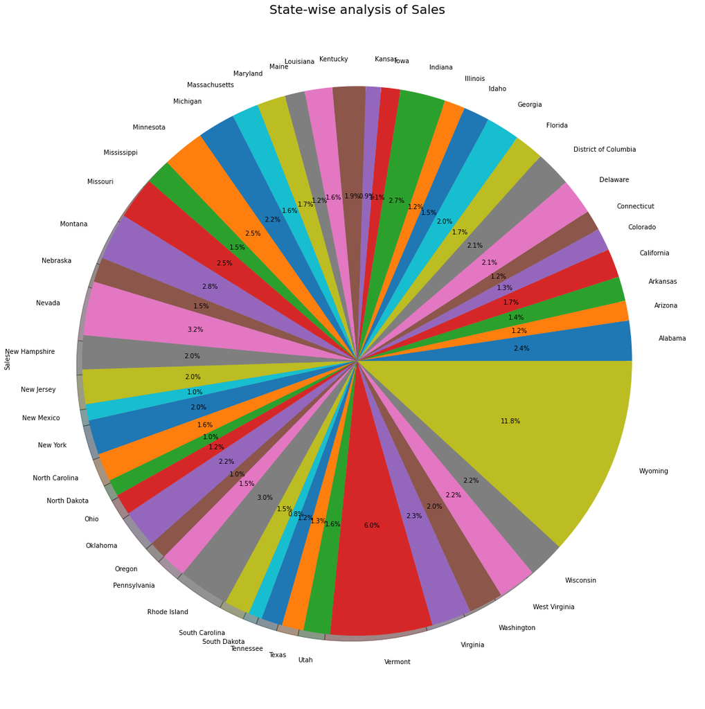

```python
df_state['Sales'].plot(kind='pie',
                        figsize = (20,20),
                        autopct='%1.1f%%',
                        startangle=0,
                        shadow=True)
mpl.title('State-wise analysis of Sales',fontsize=20)
```

The above pie chart shows the state-wise sales of the store.

**2. Statewise Discount Analysis**

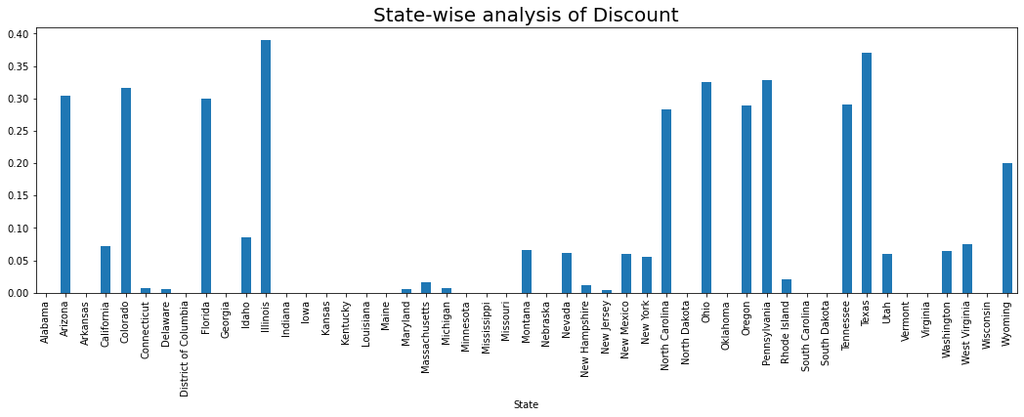

```python
df_state['Discount'].plot(kind='bar',figsize=(18,5))
mpl.title('State-wise analysis of Discount', fontsize=20)
```

The above graph shows the state-wise distribution of the discount.

- Deals in Illinois have the maximum discount on them.

**3. Statewise Profit Analysis**

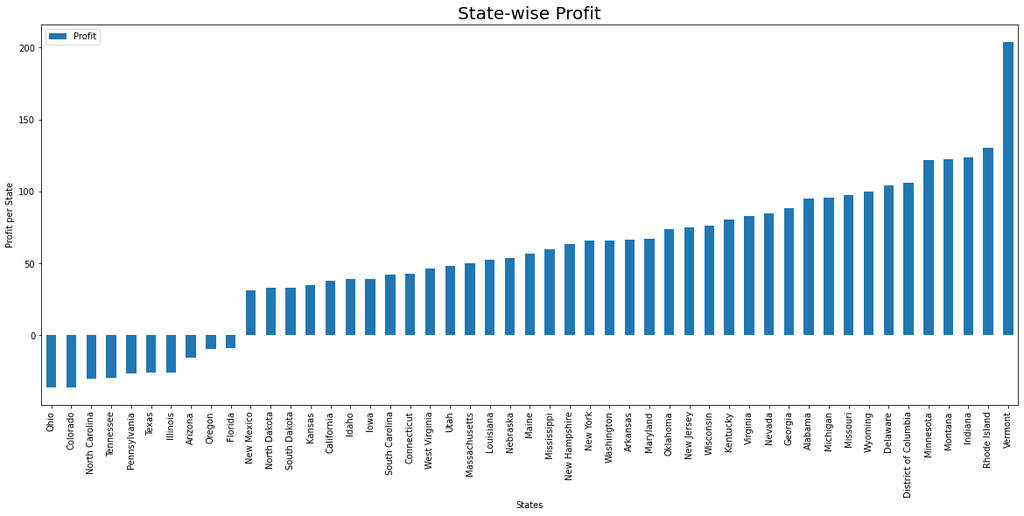

```python
df_state_profit=df_state.sort_values('Profit')

df_state_profit[['Profit']].plot(kind = 'bar', figsize = (20, 8))
mpl.title('State-wise Profit', fontsize = 20)
mpl.ylabel('Profit per State')
mpl.xlabel('States')
mpl.show()
```

The above bar graph shows the profit earned per state.

## Citywise Analysis of the Profit

```python
df_city= df.groupby(['City'])[['Sales', 'Discount', 'Profit']].mean()
df_city = df_city.sort_values('Profit')
df_city.head(15)
```

| City | Sales | Discount | Profit |
| --- | --- | --- | --- |
| Bethlehem | 337.926800 | 0.380000 | -200.619160 |
| Champaign | 151.960000 | 0.600000 | -182.352000 |
| Oswego | 107.326000 | 0.600000 | -178.709200 |
| Round Rock | 693.436114 | 0.274286 | -169.061614 |
| Lancaster | 215.031826 | 0.315217 | -157.371052 |
| Clarksville | 316.818571 | 0.271429 | -150.764743 |
| Medina | 275.302444 | 0.433333 | -149.227178 |
| Burlington | 866.723280 | 0.136000 | -144.915088 |
| San Antonio | 370.229288 | 0.383051 | -123.712715 |
| Yuma | 210.216250 | 0.450000 | -116.497725 |
| Pueblo | 210.867250 | 0.512500 | -112.621487 |
| Normal | 366.744000 | 0.300000 | -110.023200 |
| Rockford | 287.838909 | 0.509091 | -104.500709 |
| Littleton | 72.294000 | 0.700000 | -98.801800 |
| Tyler | 69.441200 | 0.640000 | -88.741720 |

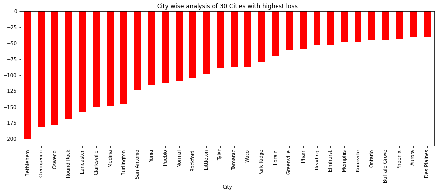

```python
df_city['Profit'].head(30).plot(kind='bar',figsize=(15,5),color = 'Red')
mpl.title('City wise analysis of 30 Cities with highest loss')
```

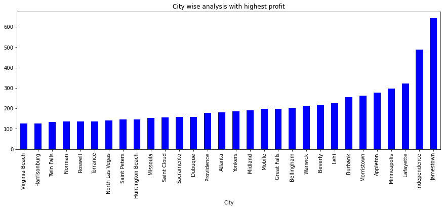

```python
df_city['Profit'].tail(30).plot(kind='bar',figsize=(15,5),color = 'Blue')
mpl.title('City wise analysis with highest profit')
```

## Quantity-wise Analysis with respect to Sales, Discount and Profit

```python
df_quantity = df.groupby(['Quantity'])[['Sales', 'Discount', 'Profit']].mean()
df_quantity.head(15)
```

| Quantity | Sales | Discount | Profit |
| --- | --- | --- | --- |
| 1 | 59.234632 | 0.152959 | 8.276396 |
| 2 | 120.354488 | 0.154858 | 16.006831 |
| 3 | 175.201578 | 0.153329 | 23.667715 |
| 4 | 271.764059 | 0.157708 | 37.131310 |
| 5 | 337.936339 | 0.157146 | 40.257394 |
| 6 | 362.101960 | 0.166556 | 18.051517 |
| 7 | 395.888393 | 0.161980 | 56.579163 |
| 8 | 458.210802 | 0.171595 | 42.244342 |
| 9 | 498.083683 | 0.147946 | 68.557716 |
| 10 | 422.046737 | 0.190702 | 35.862404 |
| 11 | 463.896529 | 0.097059 | 126.275503 |
| 12 | 646.452522 | 0.113043 | 51.524609 |
| 13 | 1197.710704 | 0.157407 | 235.144481 |
| 14 | 452.826138 | 0.151724 | 93.931166 |

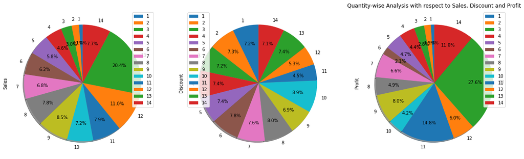

```python
df_quantity.plot.pie(subplots=True,
                    autopct='%1.1f%%',
                    figsize=(20, 20),
                     pctdistance=0.69,
                    startangle=90,     # start angle 90° (Africa)
                    shadow=True,
                    labels = df_quantity.index)
mpl.title('Quantity-wise Analysis with respect to Sales, Discount and Profit')
```

## Catagory-wise Analysis with respect to Sales, Discount and Profit

```python
df_category = df.groupby(['Category'])[['Sales', 'Discount', 'Profit']].mean()
df_category
```

| Category | Sales | Discount | Profit |
| --- | --- | --- | --- |
| Furniture | 349.834887 | 0.173923 | 8.699327 |
| Office Supplies | 119.324101 | 0.157285 | 20.327050 |
| Technology | 452.709276 | 0.132323 | 78.752002 |

```
array([<AxesSubplot:ylabel='Sales'>, <AxesSubplot:ylabel='Discount'>,
       <AxesSubplot:ylabel='Profit'>], dtype=object)
```

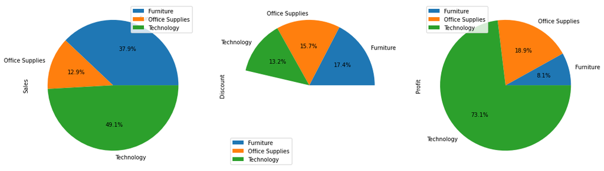

```python
df_category.plot.pie(subplots=True,
                     figsize=(18, 20),
                     autopct='%1.1f%%',
                     labels = df_category.index)
```

- Technology yields the maximum sales and profit.
- Furniture has the highest percentage of applicable.

## Sub-Category wise Analysis with respect to Sales, Discount and Profit

```python
df_sub_category = df.groupby(['Sub-Category'])[['Sales', 'Discount', 'Profit']].mean()
df_sub_category.head(15)
```

| Sub-Category | Sales | Discount | Profit |
| --- | --- | --- | --- |
| Accessories | 215.974604 | 0.078452 | 54.111788 |
| Appliances | 230.755710 | 0.166524 | 38.922758 |
| Art | 34.068834 | 0.074874 | 8.200737 |
| Binders | 133.560560 | 0.372292 | 19.843574 |
| Bookcases | 503.859633 | 0.211140 | -15.230509 |
| Chairs | 532.332420 | 0.170178 | 43.095894 |
| Copiers | 2198.941618 | 0.161765 | 817.909190 |
| Envelopes | 64.867724 | 0.080315 | 27.418019 |
| Fasteners | 13.936774 | 0.082028 | 4.375660 |
| Furnishings | 95.825668 | 0.138349 | 13.645918 |
| Labels | 34.303055 | 0.068681 | 15.236962 |
| Machines | 1645.553313 | 0.306087 | 29.432669 |
| Paper | 57.284092 | 0.074891 | 24.856620 |
| Phones | 371.211534 | 0.154556 | 50.073938 |
| Storage | 264.590553 | 0.074704 | 25.152277 |

**1. Based on Sales**

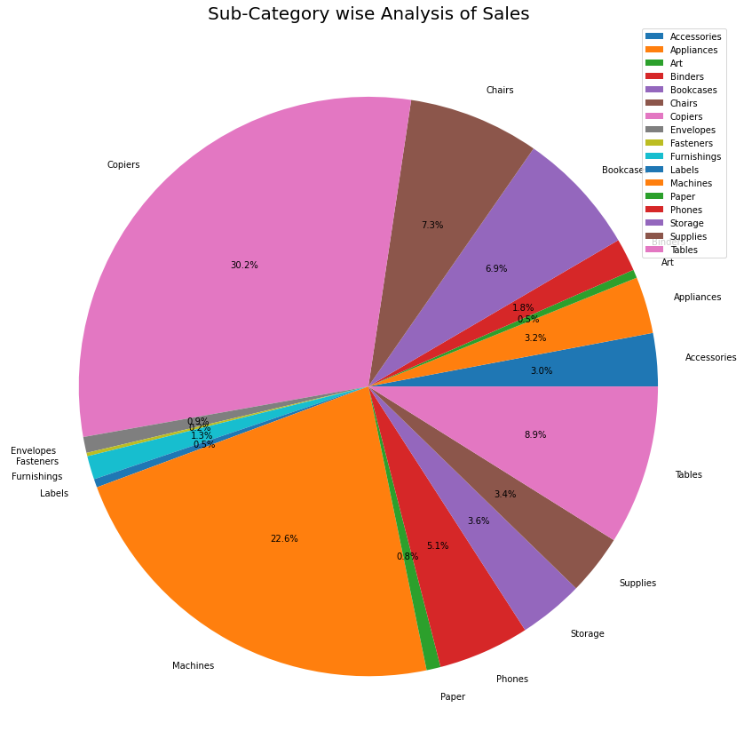

```python
mpl.figure(figsize = (15,15))
mpl.pie(df_sub_category['Sales'], labels = df_sub_category.index, autopct = '%1.1f%%')
mpl.title('Sub-Category wise Analysis of Sales', fontsize = 20)
mpl.legend()
mpl.xticks(rotation = 0)
mpl.show()
```

**2. Based on Discount**

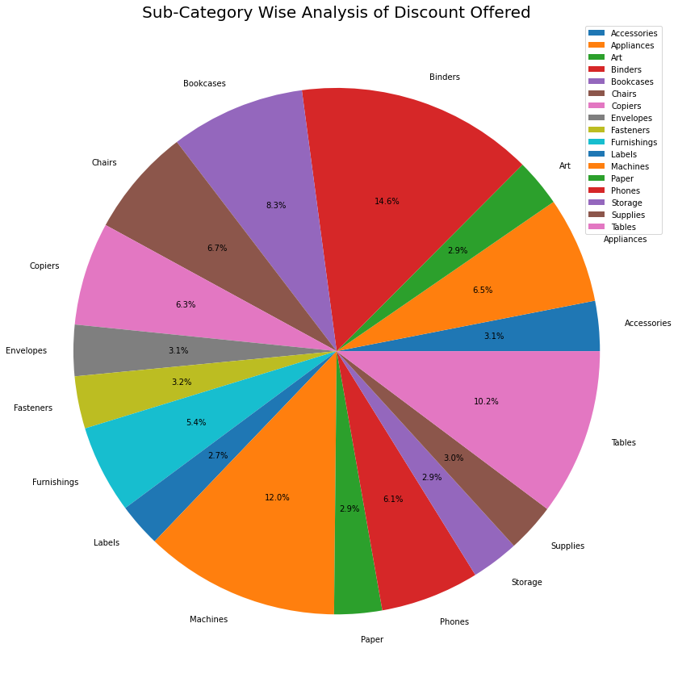

```python
mpl.figure(figsize = (15,15))
mpl.pie(df_sub_category['Discount'], labels = df_sub_category.index, autopct = '%1.1f%%')
mpl.title('Sub-Category Wise Analysis of Discount Offered', fontsize = 20)
mpl.legend()
mpl.xticks(rotation = 0)
mpl.show()
```

- Binders have the highest discount applicable with **14.6%** of the total discount offered.
- Machines have the second-highest discount applicable with **12%** of the total discount offered.
- Labels have the least discount applicable with a mere **2.7%** of the total discount offered.

**3. Based on Profit**

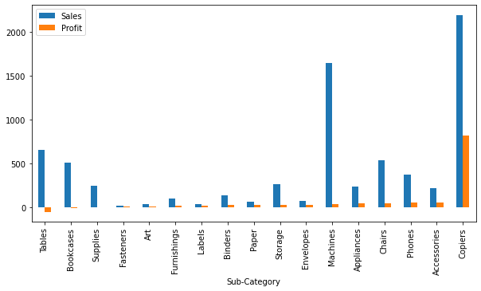

```python
df_sub_category.sort_values('Profit')[['Sales','Profit']].plot(kind='bar',
                                                              figsize= (10,5),
                                                              label=['Avg Sales Price($)','Profit($)'])
```

- Copiers have the highest amount of sales, and also generate the maximum profit.